# Positionless NBA

Anders Sorenson

3/29/2022

# Introduction

If you’ve watched the NBA in last few years you’ve probably heard something about how the NBA is becoming “positionless league”. Traditionally basketball is played with clearly defined roles and skillsets for each position (point guard, shooting guard, small forward, power forward, and center). However, many argue that the NBA has now evolved into a league where every position does a little bit of everything, including certain jobs that are traditionally performed by other positions, hence the term “positionless league”. For my final project I used box score data from 1980 to 2022 to examine if the claims that the NBA is becoming positionless could be shown through these data. If the NBA is truly becoming positionless we should be able to observe the recorded statistics for each position start to converge.

All the data used in this project comes from basketballreference.com which reports player statistics for points per game, rebounds per game, etc. In 1980 the NBA introduced the 3-point line which had a significant impact on the way each position plays the game, for this reason I choose to only use data from 1980 onward. For any statistics in which the positional average was taken, only player who played in at least 41 games and played at least 8 minutes per game were considered. I also excluded players who changed position during a season because these players statistics would naturally skew towards being positionless.

# Rebounding

To start off, let’s look at how rebounding – a skill typically most associated with Centers and Power Forward – has changed over time.

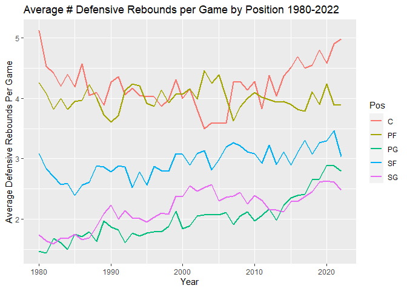

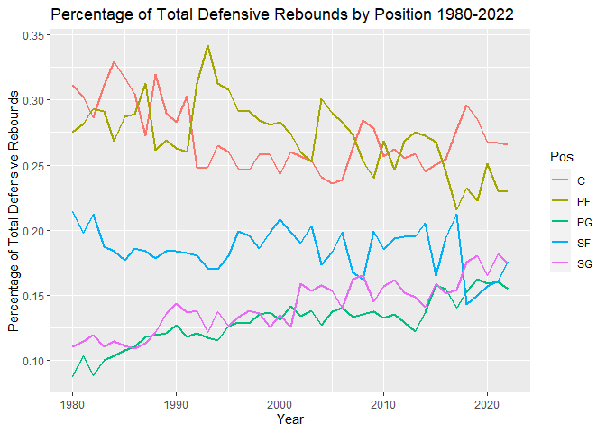

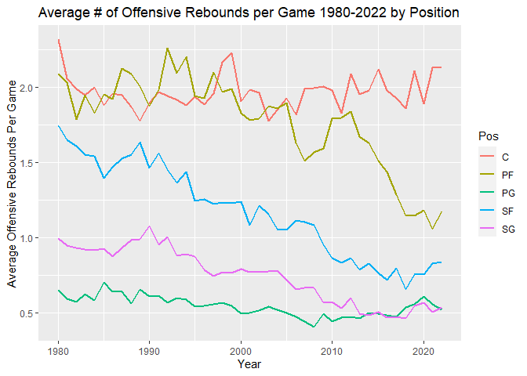

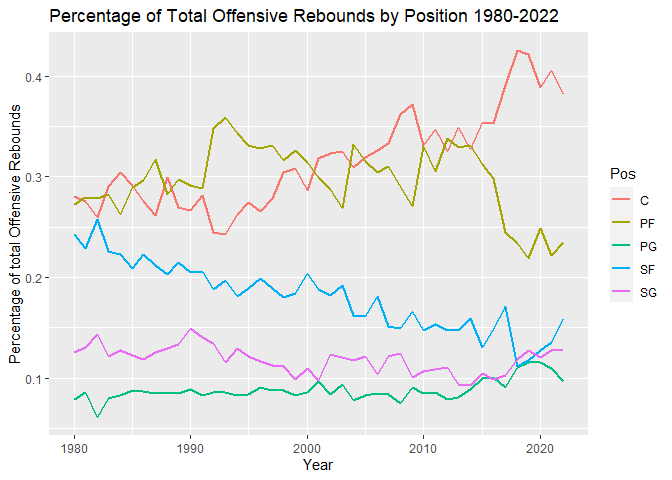

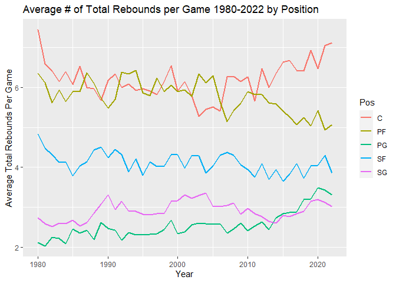

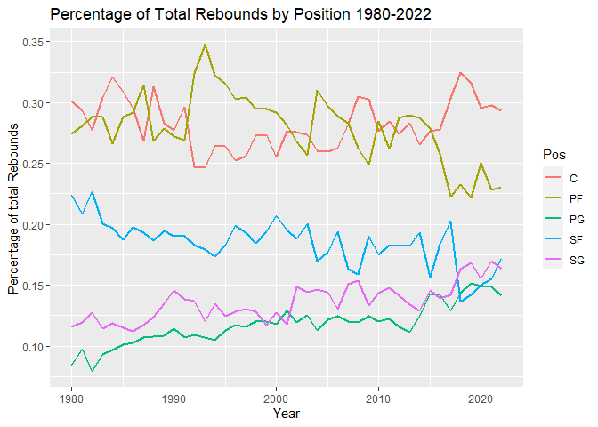

# Assists

Assists are a skill traditionally associated with back court positions, Point Guard and Shooting Guard. Let’s see if assists have become more evenly distributed by position.

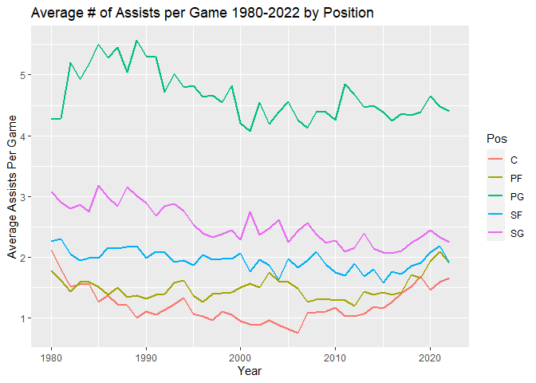

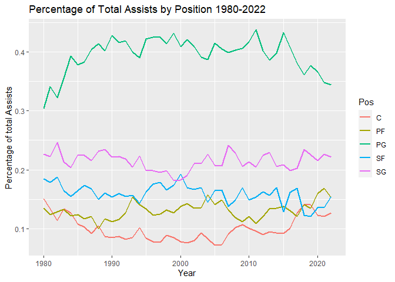

Assist numbers remain fairly constant for both guard positions and small forward. However, assist numbers for center and power forward have seen an uptick recently.

# Three Point Shooting

Now lets look at how each position has evolved in regards to three point shooting over the years.

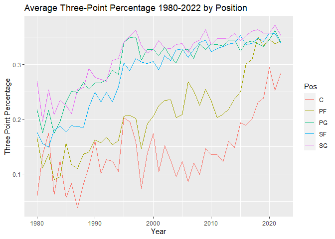

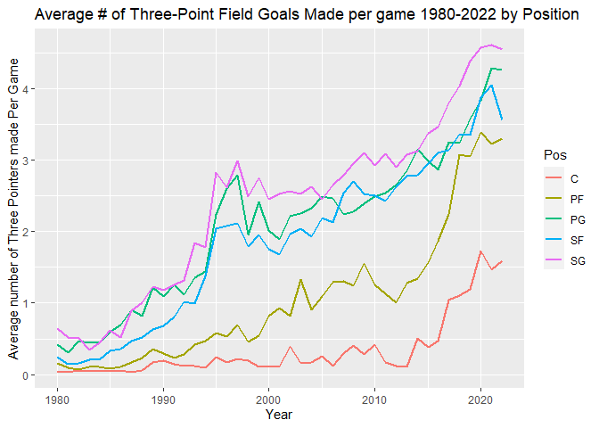

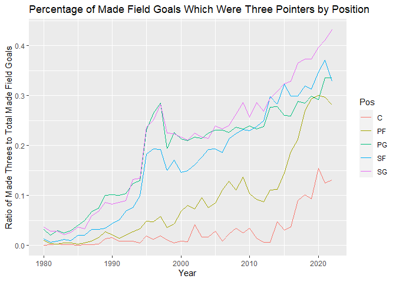

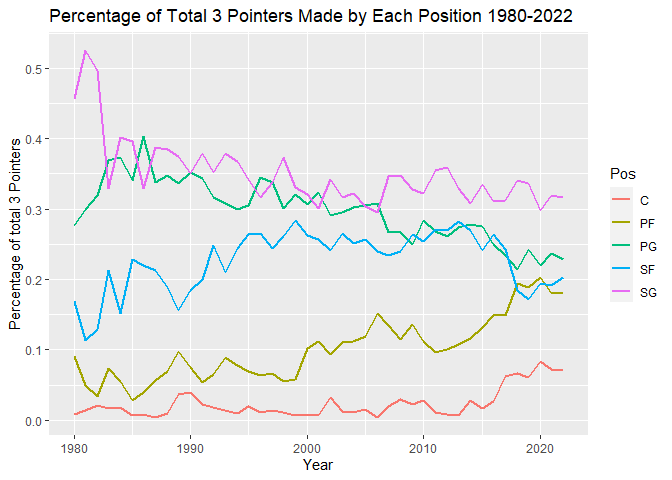

Three point percentage has greatly increased for every position since it’s addition in 1980. This statistic also shows some of the most positional change over the years, centers have increased their portion of made 3-pointers and Power forwards have almost closed the shooting gap between them and the backcourt positions.

# Blocks

Let’s take a look at blocks now…

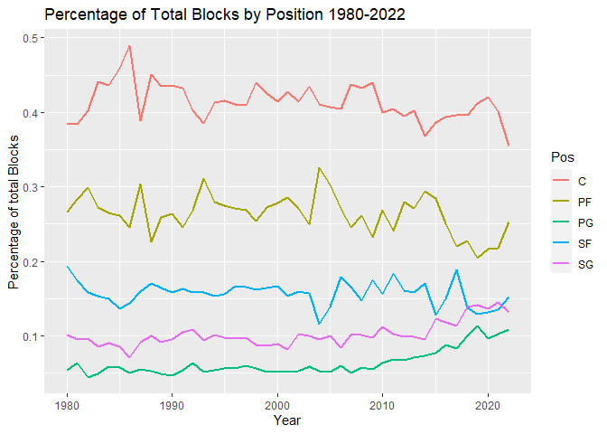

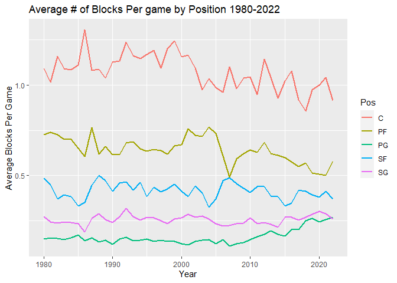

Blocks seem to have remained the most constant statistic throughout the years, although the last decade has seen an uptick in blocks by shooting guards and point guards.

## Personal Fouls

These plots demonstrate which positions account for the most fouls and how that may have changed over the years

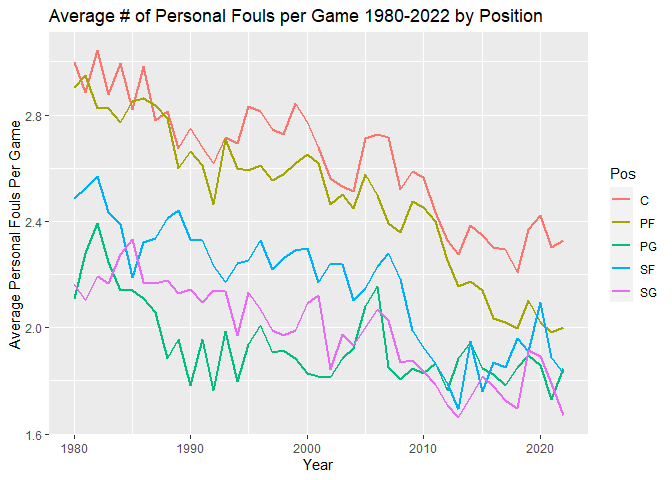

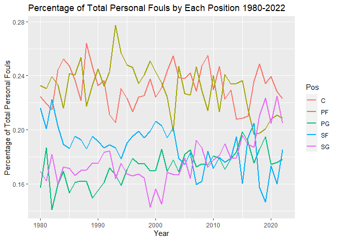

The amount of personal fouls seems to have decreased over the years but the positional relationships have remained fairly constant.

# Two Point Shooting

Since we’ve already looked at three pointers lets take a look at twos as well.

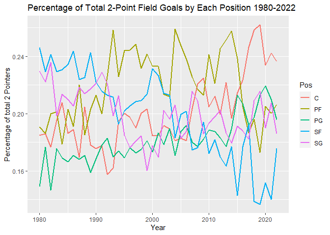

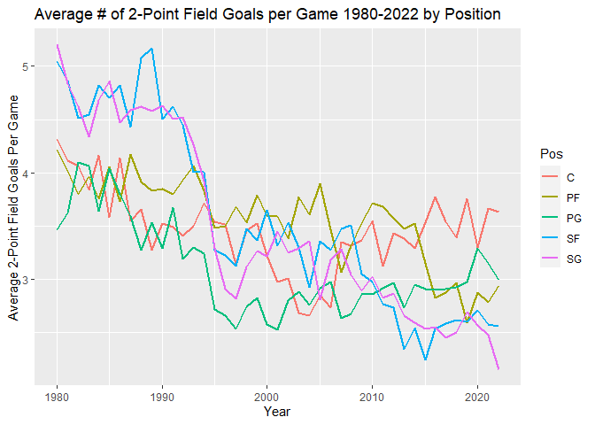

Unsurprisingly, the number of two-point field goals has decreased as the popularity of the three-point shot has risen. The proportion of total two-pointers being made by each position seems to be in a state of constant fluctuation.

# Conclusion

[Code and Data](https://github.com/AndersSorenson/AndersSorenson.github.io.git)